# Trump Ratings Summary

## Introduction

This summary explores some of the relations between **Pollster**, **Grade**, and **Rating** from FiveThirtyEight’s approval_polllist.csv.

**Pollster:** Firm that issued polls

**Grade:** Letter grade from FiveThirtyEight’s [Pollster Ratings](https://projects.fivethirtyeight.com/pollster-ratings/)

**Rating:** Consists of the Adjusted Approval and Adjusted Disapproval ratings. [This page](https://fivethirtyeight.com/features/how-were-tracking-donald-trumps-approval-ratings/) has a full description of these adjusted ratings

Following a short description of the data preparation process are 5 graphs that present a quick look at the relations in the data.

DISCLAIMER: The information in this summary excludes much of the data available from approval_polllist.csv in order to facilitate a simpler comparison of **Pollster**, **Grade**, and **Rating**. Additionally, **Pollsters** that were not assigned a **Grade** were also excluded. Because of this, the graphs below should not be interpreted as showing any significant relationship among the variables in the data, but considered as an exploratory look into certain elements of the dataset.

*I am in no way affiliated with FiveThirtyEight or their Trump Approval Ratings interactive.*

## Preparing the Data

First, a new dataframe is created with only the desired columns from approval_polllist.csv, and a factor is created for **Grade** with levels ranging from *A+* down to *D-*.

Next, any rows with N/A values for **Grade** are dropped from the dataset.

Then, Adjusted Approval and Adjusted Disapproval **Ratings** by **Pollster** were aggregated by mean into 2 unique datasets.

After aggregation, these 2 datasets were merged into 1, and a copy of this new dataset was made.

Finally, these 2 new datasets were output into csv files, one ordered alphabetically by **Pollster**, the other ordered by **Grade** level (approval_averages.csv and averages_by_grade.csv)

## Pollster Ratings Comparison

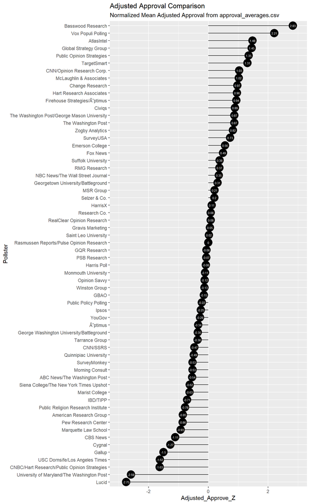

Adjusted_Approve_Z is the normalized Adjusted Approval Average across all **Pollsters**. This plot lets us see the difference in Adjusted Approval **Ratings** among **Pollsters**.

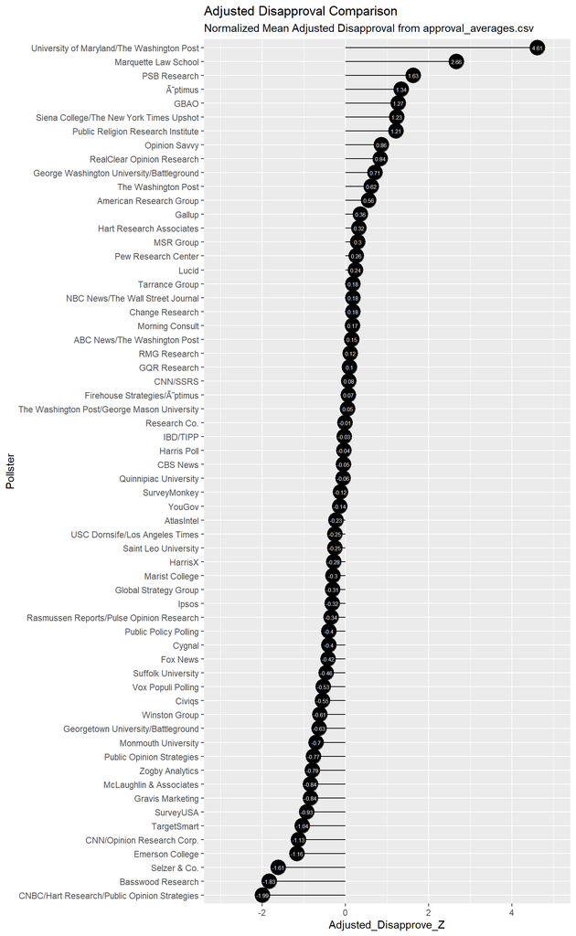

Here we see the same chart, but this time for Adjusted Disapproval **Ratings**. Some of the **Pollsters** are now on the opposite end of the y-axis, such as University of Maryland/The Washington Post and Basswood Research, and many more find themselves on the other side of 0 on the x-axis.

## Ratings Grade Comparison

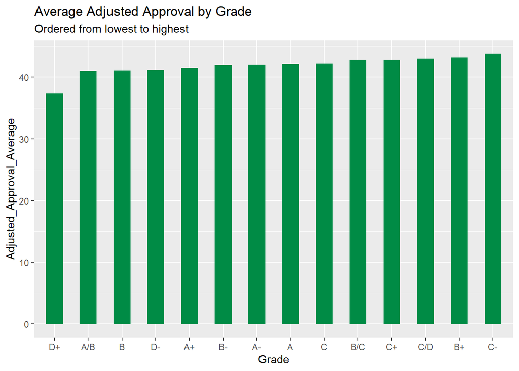

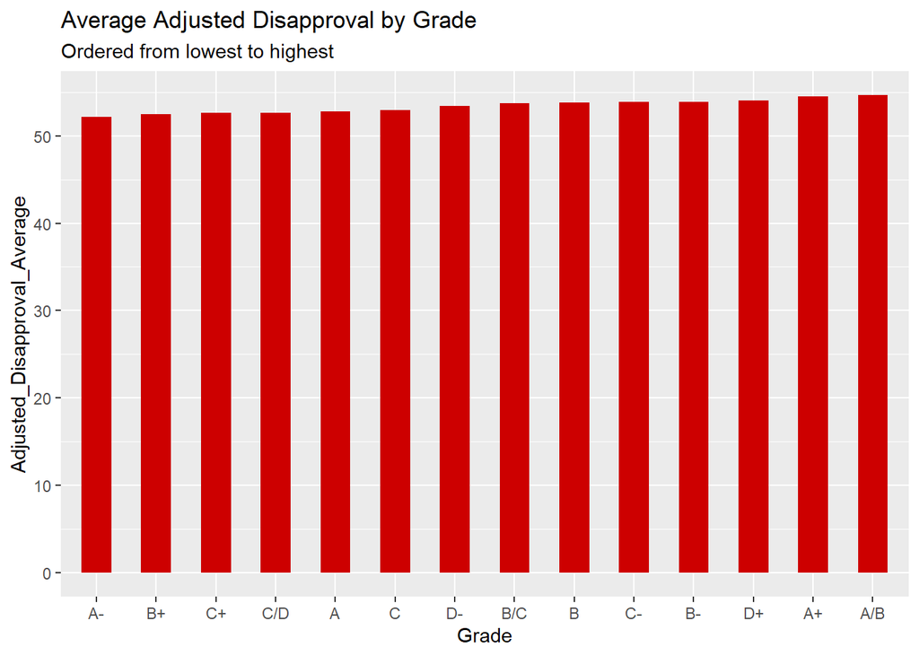

Both Adjusted Approval Average and Adjusted Disapproval Average show little variance based on grade. The graphs might look quite different if we were to use the Un-Adjusted **Ratings** instead, which may be added to this project in the near future.

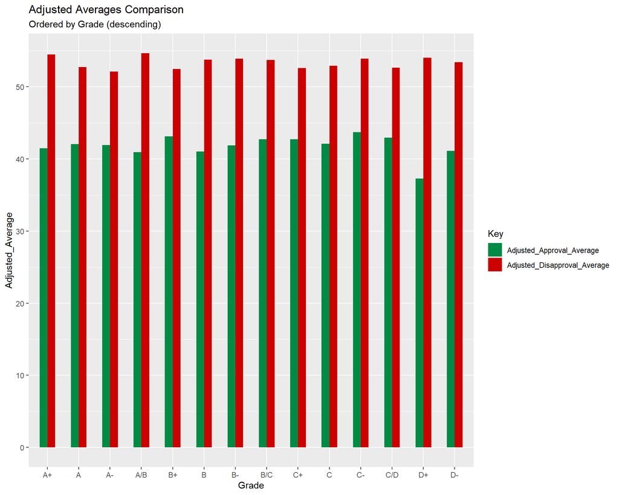

This final graph shows a side-by-side comparison of both averages, ordered from the highest to lowest grade. Despite the disclaimer above, from this visual we can derive a meaningful conclusion: red and green are fine to use in separate bar graphs, but not together in the same one (unless it’s about Christmas).

## Conclusion

This concludes our first exploration of the Trump Approval Ratings dataset. Thank you for your interest in this project. If you would like to see more of FiveThirtyEight’s interactive that inspired this small project, please use the link below.

https://projects.fivethirtyeight.com/trump-approval-ratings/